# automatization_notebook_03

2023-10-28

# Чтение данных

В вашем варианте нужно использовать датасет framingham.

```r
df= readr::read_csv('Data/framingham.csv', col_types = "iiiiiiiiiidddiii" )
spec(df)
```

# Выведите общее описание данных

```r
df_description <- df %>%
  glimpse()
```

```
## Rows: 4,238
## Columns: 16
## $ male            <int> 1, 0, 1, 0, 0, 0, 0, 0, 1, 1, 0, 0, 1, 0, 0, 0, 1, 0, …
## $ age             <int> 39, 46, 48, 61, 46, 43, 63, 45, 52, 43, 50, 43, 46, 41…
## $ education       <int> 4, 2, 1, 3, 3, 2, 1, 2, 1, 1, 1, 2, 1, 3, 2, 2, 3, 2, …
## $ currentSmoker   <int> 0, 0, 1, 1, 1, 0, 0, 1, 0, 1, 0, 0, 1, 0, 1, 1, 1, 1, …
## $ cigsPerDay      <int> 0, 0, 20, 30, 23, 0, 0, 20, 0, 30, 0, 0, 15, 0, 9, 20,…
## $ BPMeds          <int> 0, 0, 0, 0, 0, 0, 0, 0, 0, 0, 0, 0, 0, 1, 0, 0, 0, 0, …
## $ prevalentStroke <int> 0, 0, 0, 0, 0, 0, 0, 0, 0, 0, 0, 0, 0, 0, 0, 0, 0, 0, …
## $ prevalentHyp    <int> 0, 0, 0, 1, 0, 1, 0, 0, 1, 1, 0, 0, 1, 1, 0, 1, 1, 0, …
## $ diabetes        <int> 0, 0, 0, 0, 0, 0, 0, 0, 0, 0, 0, 0, 0, 0, 0, 0, 0, 0, …
## $ totChol         <int> 195, 250, 245, 225, 285, 228, 205, 313, 260, 225, 254,…
## $ sysBP           <dbl> 106.0, 121.0, 127.5, 150.0, 130.0, 180.0, 138.0, 100.0…
## $ diaBP           <dbl> 70.0, 81.0, 80.0, 95.0, 84.0, 110.0, 71.0, 71.0, 89.0,…
## $ BMI             <dbl> 26.97, 28.73, 25.34, 28.58, 23.10, 30.30, 33.11, 21.68…
## $ heartRate       <int> 80, 95, 75, 65, 85, 77, 60, 79, 76, 93, 75, 72, 98, 65…
## $ glucose         <int> 77, 76, 70, 103, 85, 99, 85, 78, 79, 88, 76, 61, 64, 8…
## $ TenYearCHD      <int> 0, 0, 0, 1, 0, 0, 1, 0, 0, 0, 0, 0, 0, 0, 0, 1, 0, 1, …
```

```r
df_description_2 <- describe(df, na.rm = TRUE, skew = FALSE, ranges = TRUE)
print(df_description_2)
```

```
##                 vars    n   mean    sd    min   max  range   se
## male               1 4238   0.43  0.50   0.00   1.0   1.00 0.01
## age                2 4238  49.58  8.57  32.00  70.0  38.00 0.13
## education          3 4133   1.98  1.02   1.00   4.0   3.00 0.02
## currentSmoker      4 4238   0.49  0.50   0.00   1.0   1.00 0.01
## cigsPerDay         5 4209   9.00 11.92   0.00  70.0  70.00 0.18
## BPMeds             6 4185   0.03  0.17   0.00   1.0   1.00 0.00
## prevalentStroke    7 4238   0.01  0.08   0.00   1.0   1.00 0.00
## prevalentHyp       8 4238   0.31  0.46   0.00   1.0   1.00 0.01
## diabetes           9 4238   0.03  0.16   0.00   1.0   1.00 0.00
## totChol           10 4188 236.72 44.59 107.00 696.0 589.00 0.69
## sysBP             11 4238 132.35 22.04  83.50 295.0 211.50 0.34
## diaBP             12 4238  82.89 11.91  48.00 142.5  94.50 0.18
## BMI               13 4219  25.80  4.08  15.54  56.8  41.26 0.06
## heartRate         14 4237  75.88 12.03  44.00 143.0  99.00 0.18
## glucose           15 3850  81.97 23.96  40.00 394.0 354.00 0.39
## TenYearCHD        16 4238   0.15  0.36   0.00   1.0   1.00 0.01
```

# Очистка данных

1. Уберите переменные, в которых пропущенных значений больше 20% или уберите субъектов со слишком большим количеством пропущенных значений. Или совместите оба варианта. Напишите обоснование, почему вы выбрали тот или иной вариант:

```r
na_count_cols <- colSums(is.na(df))
na_count_cols #Сколько N/A в каждом столбце
```

```
##            male             age       education   currentSmoker      cigsPerDay
##               0               0             105               0              29
##          BPMeds prevalentStroke    prevalentHyp        diabetes         totChol
##              53               0               0               0              50
##           sysBP           diaBP             BMI       heartRate         glucose
##               0               0              19               1             388
##      TenYearCHD
##               0
```

```r
percent_na_glucose <- na_count_cols["glucose"] / nrow(df) * 100
percent_na_glucose #Процент N/A в переменной glucose
```

```
##  glucose
## 9.155262
```

```r
na_count_rows <- df %>%
  rowwise() %>%
  mutate(na_count = sum(is.na(c_across(everything()))))

na_count_rows_summary <- na_count_rows %>%
  count(na_count)
na_count_rows_summary #Количество строк в датасете с разным количеством N/A
```

| na_count | n |
| --- | --- |
| 0 | 3656 |
| 1 | 521 |
| 2 | 59 |
| 3 | 2 |

```r
df_clean <- df %>%
  filter(rowSums(is.na(.)) < 2) #Чистим датасет, чтобы в одной строке не было двух и более NA
```

2. Переименуйте переменные в человекочитаемый вид (что делать с пробелами в названиях?);

```r
library(stringi)
df_clean <- df_clean %>%
  rename_with(function(x) x %>% stri_replace_all_regex(c("male", "age", "education", "currentSmoker", "cigsPerDay", "BPMeds", "prevalentStroke", "prevalentHyp", "diabetes", "totChol", "sysBP", "diaBP", "BMI", "heartRate", "glucose", "TenYearCHD"), c("Мужской пол", "Возраст", "Образование", "Курит", "Сигарет в день", "Антигипертоническая терапия", "Инсульт", "Гипертензия", "Диабет", "Общий холестерол", "АД-систолическое", "АД-диастолическое", "Индекс массы тела", "Частота сердцебиения", "Глюкоза", "Риск CDH"), vectorise_all = FALSE)) %>%
  glimpse()
```

```
## Rows: 4,177
## Columns: 16
## $ `Мужской пол`                 <int> 1, 0, 1, 0, 0, 0, 0, 0, 1, 1, 0, 0, 1, 0…
## $ Возраст                       <int> 39, 46, 48, 61, 46, 43, 63, 45, 52, 43, …
## $ Образование                   <int> 4, 2, 1, 3, 3, 2, 1, 2, 1, 1, 1, 2, 1, 3…
## $ Курит                         <int> 0, 0, 1, 1, 1, 0, 0, 1, 0, 1, 0, 0, 1, 0…
## $ `Сигарет в день`              <int> 0, 0, 20, 30, 23, 0, 0, 20, 0, 30, 0, 0,…
## $ `Антигипертоническая терапия` <int> 0, 0, 0, 0, 0, 0, 0, 0, 0, 0, 0, 0, 0, 1…
## $ Инсульт                       <int> 0, 0, 0, 0, 0, 0, 0, 0, 0, 0, 0, 0, 0, 0…
## $ Гипертензия                   <int> 0, 0, 0, 1, 0, 1, 0, 0, 1, 1, 0, 0, 1, 1…
## $ Диабет                        <int> 0, 0, 0, 0, 0, 0, 0, 0, 0, 0, 0, 0, 0, 0…
## $ `Общий холестерол`            <int> 195, 250, 245, 225, 285, 228, 205, 313, …
## $ `АД-систолическое`            <dbl> 106.0, 121.0, 127.5, 150.0, 130.0, 180.0…
## $ `АД-диастолическое`           <dbl> 70.0, 81.0, 80.0, 95.0, 84.0, 110.0, 71.…
## $ `Индекс массы тела`           <dbl> 26.97, 28.73, 25.34, 28.58, 23.10, 30.30…
## $ `Частота сердцебиения`        <int> 80, 95, 75, 65, 85, 77, 60, 79, 76, 93, …
## $ Глюкоза                       <int> 77, 76, 70, 103, 85, 99, 85, 78, 79, 88,…
## $ `Риск CDH`                    <int> 0, 0, 0, 1, 0, 0, 1, 0, 0, 0, 0, 0, 0, 0…
```

3. В соответствии с описанием данных приведите переменные к нужному типу (numeric или factor);

```r
df_clean <- df_clean %>%
  mutate(`Мужской пол` = factor(`Мужской пол`, levels = c(0, 1), labels = c("Нет", "Да")), Образование = as.factor(Образование), Курит = as.factor(Курит), `Антигипертоническая терапия` = as.factor(`Антигипертоническая терапия`), Инсульт = as.factor(Инсульт), Гипертензия = as.factor(Гипертензия), Диабет = as.factor(Диабет), `Риск CDH` = as.factor(`Риск CDH`))

str(df_clean)
```

```
## tibble [4,177 × 16] (S3: tbl_df/tbl/data.frame)
##  $ Мужской пол                : Factor w/ 2 levels "Нет","Да": 2 1 2 1 1 1 1 1 2 2 ...
##  $ Возраст                    : int [1:4177] 39 46 48 61 46 43 63 45 52 43 ...
##  $ Образование                : Factor w/ 4 levels "1","2","3","4": 4 2 1 3 3 2 1 2 1 1 ...
##  $ Курит                      : Factor w/ 2 levels "0","1": 1 1 2 2 2 1 1 2 1 2 ...
##  $ Сигарет в день             : int [1:4177] 0 0 20 30 23 0 0 20 0 30 ...
##  $ Антигипертоническая терапия: Factor w/ 2 levels "0","1": 1 1 1 1 1 1 1 1 1 1 ...
##  $ Инсульт                    : Factor w/ 2 levels "0","1": 1 1 1 1 1 1 1 1 1 1 ...
##  $ Гипертензия                : Factor w/ 2 levels "0","1": 1 1 1 2 1 2 1 1 2 2 ...
##  $ Диабет                     : Factor w/ 2 levels "0","1": 1 1 1 1 1 1 1 1 1 1 ...
##  $ Общий холестерол           : int [1:4177] 195 250 245 225 285 228 205 313 260 225 ...
##  $ АД-систолическое           : num [1:4177] 106 121 128 150 130 ...
##  $ АД-диастолическое          : num [1:4177] 70 81 80 95 84 110 71 71 89 107 ...
##  $ Индекс массы тела          : num [1:4177] 27 28.7 25.3 28.6 23.1 ...
##  $ Частота сердцебиения       : int [1:4177] 80 95 75 65 85 77 60 79 76 93 ...
##  $ Глюкоза                    : int [1:4177] 77 76 70 103 85 99 85 78 79 88 ...
##  $ Риск CDH                   : Factor w/ 2 levels "0","1": 1 1 1 2 1 1 2 1 1 1 ...
```

4. Отсортируйте данные по возрасту по убыванию;

```r
df_clean <- df_clean %>%
  arrange(desc(`Возраст`))
```

5. Сохраните в файл outliers.csv субъектов, которые являются выбросами (например, по правилу трёх сигм) — это необязательное задание со звёздочкой;

```r
df_clean <- df_clean %>%
  mutate(`ID` = row_number())

numeric_vars <- df_clean %>%
  select_if(is.numeric) %>%
  names()

outliers_list <- list() #список для хранения выбросов

for (var in numeric_vars) {
  mean_value <- mean(df_clean[[var]], na.rm = TRUE)
  std_value <- sd(df_clean[[var]], na.rm = TRUE)
  lower_bound <- mean_value - 3 * std_value
  upper_bound <- mean_value + 3 * std_value
  outliers_data <- df_clean %>%
    filter((!!sym(var) < lower_bound) | (!!sym(var) > upper_bound))
  outliers_list[[var]] <- outliers_data
}

all_outliers <- bind_rows(outliers_list) %>%
  distinct()

df_outliers <- write.csv(all_outliers, "outliers.csv", row.names = FALSE)
str(all_outliers)
```

```
## tibble [226 × 17] (S3: tbl_df/tbl/data.frame)
##  $ Мужской пол                : Factor w/ 2 levels "Нет","Да": 2 2 2 2 2 2 2 2 2 2 ...
##  $ Возраст                    : int [1:226] 67 59 58 56 55 53 51 50 49 49 ...
##  $ Образование                : Factor w/ 4 levels "1","2","3","4": 2 1 2 1 1 1 1 1 2 2 ...
##  $ Курит                      : Factor w/ 2 levels "0","1": 2 2 2 2 2 2 2 2 2 2 ...
##  $ Сигарет в день             : int [1:226] 60 60 60 60 45 50 50 60 50 60 ...
##  $ Антигипертоническая терапия: Factor w/ 2 levels "0","1": 1 1 1 1 1 1 1 1 1 1 ...
##  $ Инсульт                    : Factor w/ 2 levels "0","1": 1 1 1 1 1 1 1 1 1 1 ...
##  $ Гипертензия                : Factor w/ 2 levels "0","1": 2 2 2 1 1 1 1 2 1 1 ...
##  $ Диабет                     : Factor w/ 2 levels "0","1": 1 1 1 1 1 1 1 1 1 1 ...
##  $ Общий холестерол           : int [1:226] 261 298 250 246 345 306 335 340 252 213 ...
##  $ АД-систолическое           : num [1:226] 170 154 150 125 134 ...
##  $ АД-диастолическое          : num [1:226] 100 105 97 79 89 82.5 94 95 91 75 ...
##  $ Индекс массы тела          : num [1:226] 22.7 25.1 32 29.6 27.4 ...
##  $ Частота сердцебиения       : int [1:226] 72 70 75 70 72 72 80 85 70 70 ...
##  $ Глюкоза                    : int [1:226] 79 84 65 85 60 NA 67 86 114 NA ...
##  $ Риск CDH                   : Factor w/ 2 levels "0","1": 2 1 1 1 1 1 1 1 2 2 ...
##  $ ID                         : int [1:226] 68 694 820 1039 1250 1442 1751 1898 2045 2071 ...
```

6. Присвойте получившийся датасет переменной “cleaned_data”.

```r
cleaned_data <- df_clean %>%
  anti_join(all_outliers, by = "ID") #удаляем все строки с выбросами

cleaned_data <- cleaned_data %>%
  select(-ID)

str(cleaned_data)
```

```
## tibble [3,951 × 16] (S3: tbl_df/tbl/data.frame)
##  $ Мужской пол                : Factor w/ 2 levels "Нет","Да": 1 1 1 1 2 1 2 2 1 2 ...
##  $ Возраст                    : int [1:3951] 70 70 69 69 69 69 69 69 69 68 ...
##  $ Образование                : Factor w/ 4 levels "1","2","3","4": 1 2 2 3 1 3 1 NA 2 1 ...
##  $ Курит                      : Factor w/ 2 levels "0","1": 1 1 1 1 2 1 2 2 1 1 ...
##  $ Сигарет в день             : int [1:3951] 0 0 0 0 4 0 1 23 0 0 ...
##  $ Антигипертоническая терапия: Factor w/ 2 levels "0","1": 1 2 1 1 1 2 1 1 2 1 ...
##  $ Инсульт                    : Factor w/ 2 levels "0","1": 2 1 1 1 1 1 1 1 1 1 ...
##  $ Гипертензия                : Factor w/ 2 levels "0","1": 2 2 2 1 2 2 1 2 2 2 ...
##  $ Диабет                     : Factor w/ 2 levels "0","1": 1 1 1 1 1 1 1 1 1 2 ...
##  $ Общий холестерол           : int [1:3951] 107 231 215 286 232 203 245 186 220 164 ...
##  $ АД-систолическое           : num [1:3951] 143 136 164 117 151 166 123 179 143 142 ...
##  $ АД-диастолическое          : num [1:3951] 93 84 80 73 74 90 77 93 81 85 ...
##  $ Индекс массы тела          : num [1:3951] NA 31.8 17.2 20.9 24.1 ...
##  $ Частота сердцебиения       : int [1:3951] 68 60 100 85 75 77 70 72 60 70 ...
##  $ Глюкоза                    : int [1:3951] 62 95 NA 103 62 80 81 67 77 120 ...
##  $ Риск CDH                   : Factor w/ 2 levels "0","1": 2 1 1 1 1 1 2 1 1 2 ...
```

# Сколько осталось переменных?

```r
nrow(cleaned_data)
```

```
## [1] 3951
```

# Сколько осталось случаев?

```r
CDH_cases <- sum(cleaned_data$`Риск CDH`==1)
CDH_cases
```

```
## [1] 552
```

# Есть ли в данных идентичные строки?

```r
identical_rows <- cleaned_data[duplicated(cleaned_data), ]
identical_rows
```

| Мужской пол | Возраст | Образование | Курит | Сигарет в день | Антигипертоническая терапия | Инсульт | Гипертензия | Диабет | Общий холестерол | АД-систолическое | АД-диастолическое | Индекс массы тела | Частота сердцебиения | Глюкоза | Риск CDH |
| --- | --- | --- | --- | --- | --- | --- | --- | --- | --- | --- | --- | --- | --- | --- | --- |

```r
unique_data <- cleaned_data %>% distinct()
unique_data #Строк столько же, значит все строки уникальные
```

| Мужской пол | Возраст | Образование | Курит | Сигарет в день | Антигипертоническая терапия | Инсульт | Гипертензия | Диабет | Общий холестерол | АД-систолическое | АД-диастолическое | Индекс массы тела | Частота сердцебиения | Глюкоза | Риск CDH |
| --- | --- | --- | --- | --- | --- | --- | --- | --- | --- | --- | --- | --- | --- | --- | --- |
| Нет | 70 | 1 | 0 | 0 | 0 | 1 | 1 | 0 | 107 | 143.0 | 93.0 | NA | 68 | 62 | 1 |
| Нет | 70 | 2 | 0 | 0 | 1 | 0 | 1 | 0 | 231 | 136.0 | 84.0 | 31.78 | 60 | 95 | 0 |
| Нет | 69 | 2 | 0 | 0 | 0 | 0 | 1 | 0 | 215 | 164.0 | 80.0 | 17.23 | 100 | NA | 0 |
| Нет | 69 | 3 | 0 | 0 | 0 | 0 | 0 | 0 | 286 | 117.0 | 73.0 | 20.92 | 85 | 103 | 0 |
| Да | 69 | 1 | 1 | 4 | 0 | 0 | 1 | 0 | 232 | 151.0 | 74.0 | 24.14 | 75 | 62 | 0 |
| Нет | 69 | 3 | 0 | 0 | 1 | 0 | 1 | 0 | 203 | 166.0 | 90.0 | 25.40 | 77 | 80 | 0 |
| Да | 69 | 1 | 1 | 1 | 0 | 0 | 0 | 0 | 245 | 123.0 | 77.0 | 26.58 | 70 | 81 | 1 |
| Да | 69 | NA | 1 | 23 | 0 | 0 | 1 | 0 | 186 | 179.0 | 93.0 | 26.64 | 72 | 67 | 0 |
| Нет | 69 | 2 | 0 | 0 | 1 | 0 | 1 | 0 | 220 | 143.0 | 81.0 | 26.27 | 60 | 77 | 0 |
| Да | 68 | 1 | 0 | 0 | 0 | 0 | 1 | 1 | 164 | 142.0 | 85.0 | 30.28 | 70 | 120 | 1 |

[output cut: 3941 more lines]

# Сколько всего переменных с пропущенными значениями в данных и сколько пропущенных точек в каждой такой переменной?

```r
missing_summary <- cleaned_data %>%
  summarize(
    vars_with_missing = sum(across(everything(), ~is.na(.))),
    missing_per_variable = across(everything(), ~sum(is.na(.)))
  )

print(missing_summary$vars_with_missing) #Всего 495 N/A
```

```
## [1] 495
```

```r
print(missing_summary$missing_per_variable) #N/A в каждой переменной
```

```
## # A tibble: 1 × 17
##   `Мужской пол` Возраст Образование Курит `Сигарет в день`
##           <int>   <int>       <int> <int>            <int>
## 1             0       0          88     0               22
## # ℹ 12 more variables: `Антигипертоническая терапия` <int>, Инсульт <int>,
## #   Гипертензия <int>, Диабет <int>, `Общий холестерол` <int>,
## #   `АД-систолическое` <int>, `АД-диастолическое` <int>,
## #   `Индекс массы тела` <int>, `Частота сердцебиения` <int>, Глюкоза <int>,
## #   `Риск CDH` <int>, vars_with_missing <int>
```

# Описательные статистики

## Количественные переменные

1. Рассчитайте для всех количественных переменных для каждой группы (TenYearCHD):

1.1) Количество значений;

1.2) Количество пропущенных значений;

1.3) Среднее;

1.4) Медиану;

1.5) Стандартное отклонение;

1.6) 25% квантиль и 75% квантиль;

1.7) Интерквартильный размах;

1.8) Минимум;

1.9) Максимум;

1.10) 95% ДИ для среднего - задание со звёздочкой.

```r
numeric_vars <- cleaned_data %>%
  select_if(is.numeric) %>%
  names()

# Список функций для расчета статистики
statistics <- list(
  `Количество значений` = ~length(.x),
  `Количество пропущенных значений` = ~sum(is.na(.x)),
  `Среднее значение` = ~ifelse(sum(!is.na(.x)) == 0, "Н/П*", mean(.x, na.rm = TRUE) %>% round(2) %>% as.character()),
  `Медиана` = ~ifelse(sum(!is.na(.x)) == 0, "Н/П*", median(.x, na.rm = TRUE) %>% round(2) %>% as.character()),
  `Станд. отклон.` = ~ifelse(sum(!is.na(.x)) < 3, "Н/П*", sd(.x, na.rm = TRUE) %>% round(2) %>% as.character()),
  `мин. - макс.` = ~ifelse(sum(!is.na(.x)) == 0, "Н/П*", paste0(min(.x, na.rm = TRUE) %>% round(2), " - ", max(.x, na.rm = TRUE) %>% round(2))),
  `95% ДИ для среднего` = ~ifelse(sum(!is.na(.x)) == 0, "Н/П*", paste0((mean(.x, na.rm = TRUE) - qnorm(0.975) * (sd(.x, na.rm = TRUE)/sqrt(length(.x)))) %>% round(2), " - ", (mean(.x, na.rm = TRUE) + qnorm(0.975) * (sd(.x, na.rm = TRUE)/sqrt(length(.x)))) %>% round(2))),
  `Интерквартильный размах` = ~quantile(.x, 0.75, na.rm = TRUE) - quantile(.x, 0.25, na.rm = TRUE)
)

# Расчет статистики для каждой числовой переменной, сгруппированной по `Риск CDH`

df_statistics_numeric <- cleaned_data %>%
  group_by(`Риск CDH`) %>%
  summarise(across(all_of(numeric_vars), statistics, .names = "{.fn}__{.col}")) %>%
  mutate(across(everything(), as.character)) %>%
  pivot_longer(
    cols = -`Риск CDH`,
    names_to = c("Статистика", "Переменная"),
    names_sep = "__",
    values_to = "Value"
  )

print(df_statistics_numeric)
```

```
## # A tibble: 128 × 4
##    `Риск CDH` Статистика                      Переменная     Value
##    <chr>      <chr>                           <chr>          <chr>
##  1 0          Количество значений             Возраст        3399
##  2 0          Количество пропущенных значений Возраст        0
##  3 0          Среднее значение                Возраст        48.56
##  4 0          Медиана                         Возраст        47
##  5 0          Станд. отклон.                  Возраст        8.34
##  6 0          мин. - макс.                    Возраст        32 - 70
##  7 0          95% ДИ для среднего             Возраст        48.28 - 48.84
##  8 0          Интерквартильный размах         Возраст        13
##  9 0          Количество значений             Сигарет в день 3399
## 10 0          Количество пропущенных значений Сигарет в день 21
## # ℹ 118 more rows
```

## Категориальные переменные

1. Рассчитайте для всех категориальных переменных для каждой группы (TenYearCHD):

1.1) Абсолютное количество;

1.2) Относительное количество внутри группы;

1.3) 95% ДИ для доли внутри группы - задание со звёздочкой.

```r
categorical_vars <- cleaned_data %>%
  select_if(is.factor) %>%
  select(-`Риск CDH`) %>%
  names()


df_statistics_categoric <- cleaned_data %>%
  select(all_of(categorical_vars), `Риск CDH`) %>%
  pivot_longer(cols = all_of(categorical_vars), names_to = "Переменная", values_to = "Значение") %>%
  group_by(`Риск CDH`, Переменная, Значение) %>%
  summarise(`Абсолютное количество` = n(), .groups = "drop") %>%
  mutate(`Относительное количество` = `Абсолютное количество` / sum(`Абсолютное количество`))

df_statistics_categoric
```

| Риск CDH | Переменная | Значение | Абсолютное количество | Относительное количество |
| --- | --- | --- | --- | --- |
| 0 | Антигипертоническая терапия | 1 | 72 | 0.0026033192 |
| 0 | Антигипертоническая терапия | 0 | 3292 | 0.1190295404 |
| 0 | Антигипертоническая терапия | NA | 35 | 0.0012655024 |
| 0 | Гипертензия | 1 | 884 | 0.0319629750 |
| 0 | Гипертензия | 0 | 2515 | 0.0909353871 |
| 0 | Диабет | 1 | 38 | 0.0013739740 |
| 0 | Диабет | 0 | 3361 | 0.1215243880 |
| 0 | Инсульт | 1 | 12 | 0.0004338865 |
| 0 | Инсульт | 0 | 3387 | 0.1224644755 |
| 0 | Курит | 1 | 1670 | 0.0603825433 |

[output cut: 26 more lines]

# Визуализация

## Количественные переменные

1. Для каждой количественной переменной сделайте боксплоты по группам. Расположите их либо на отдельных рисунках, либо на одном, но читаемо;
2. Наложите на боксплоты beeplots - задание со звёздочкой.
3. Раскрасьте боксплоты с помощью библиотеки RColorBrewer.

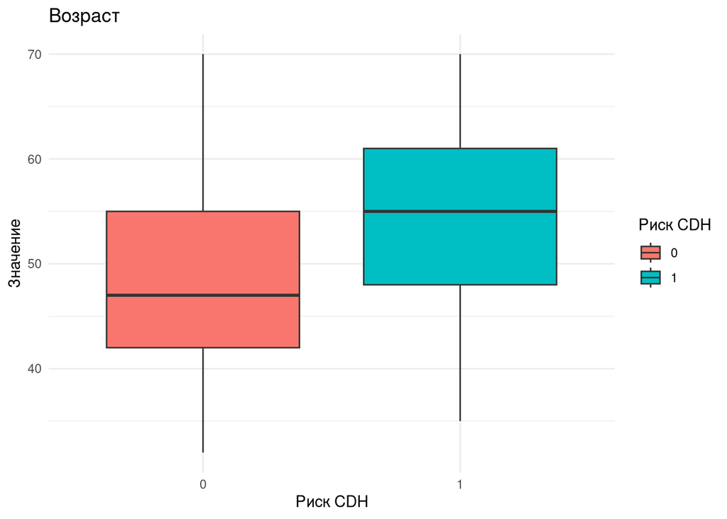

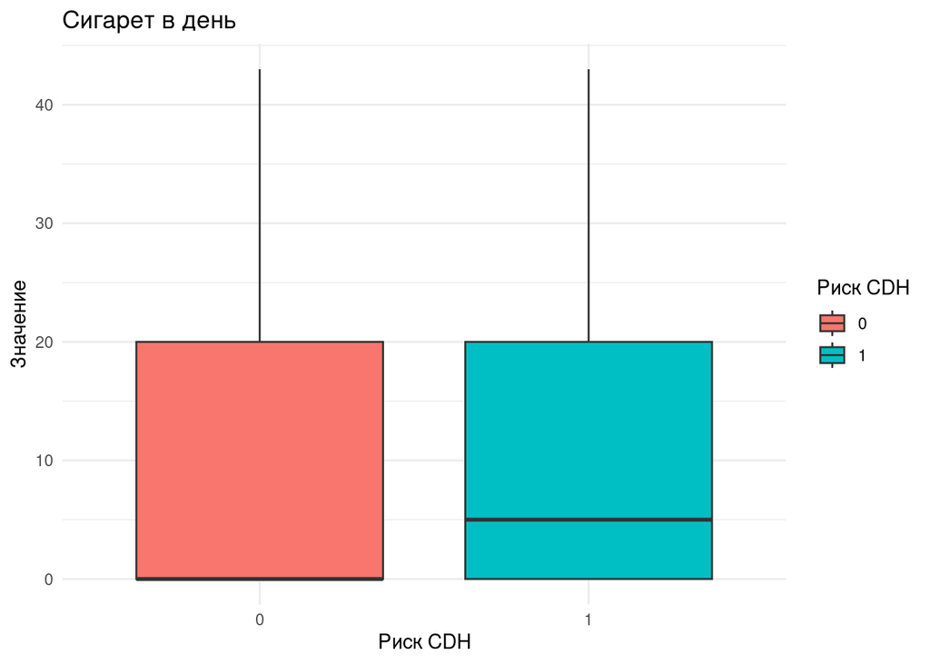

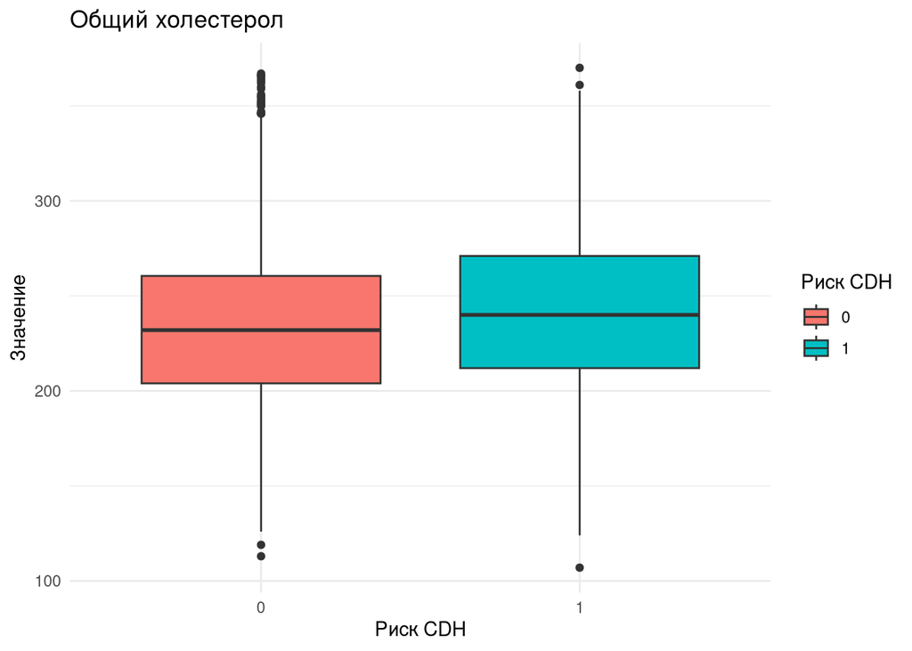

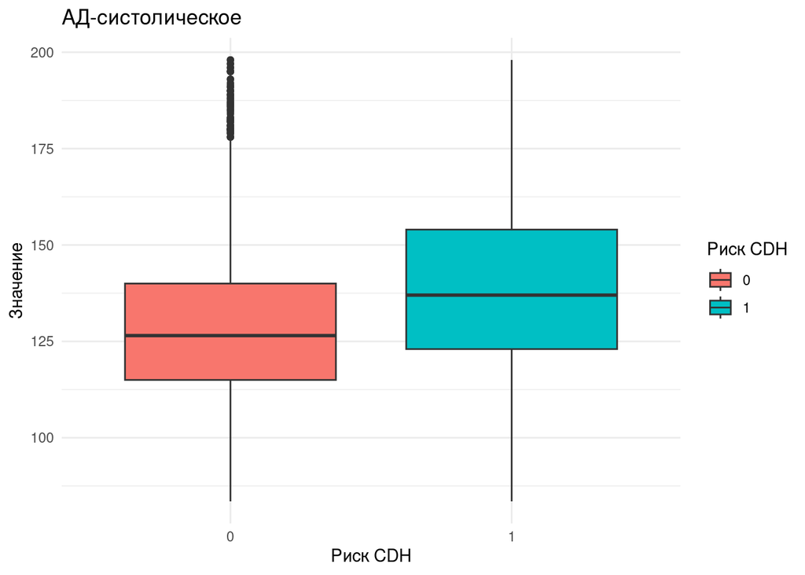

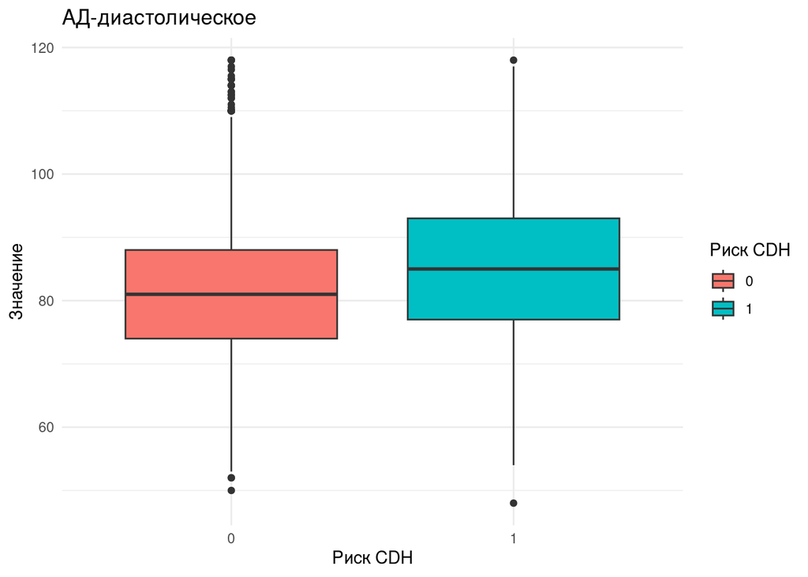

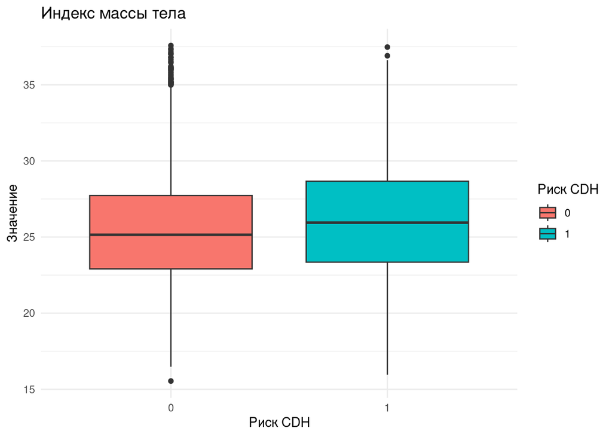

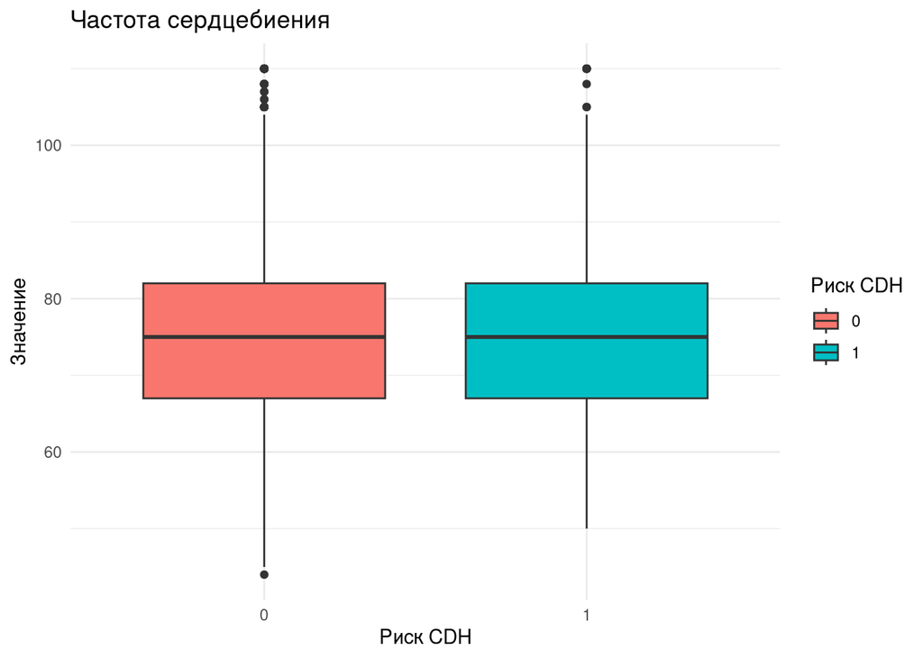

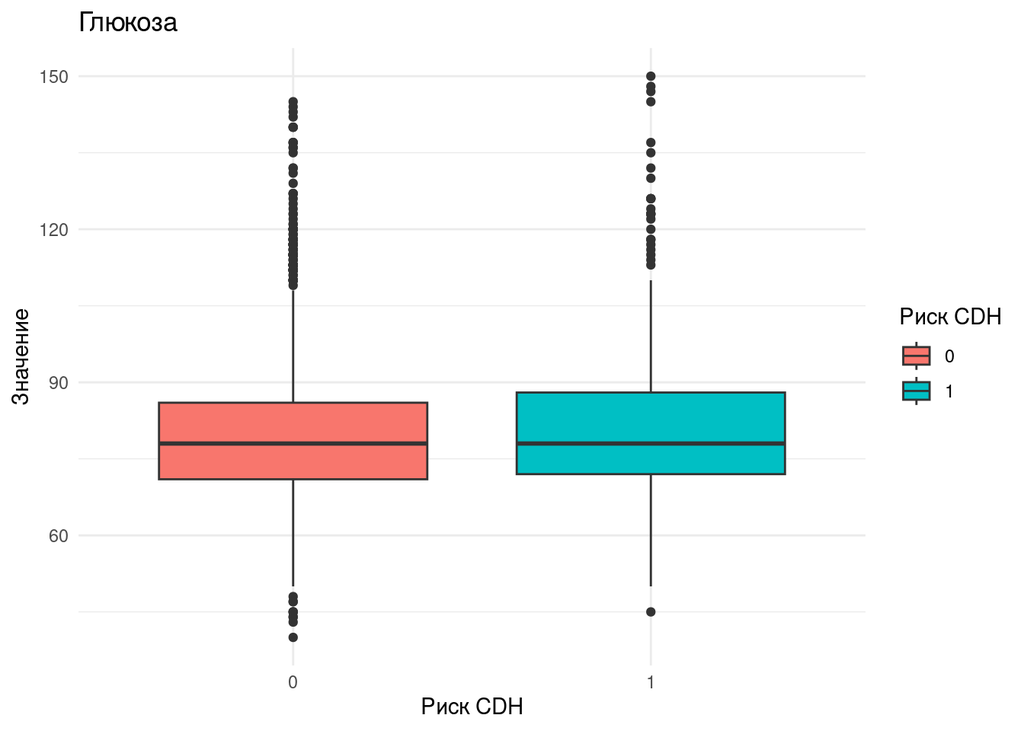

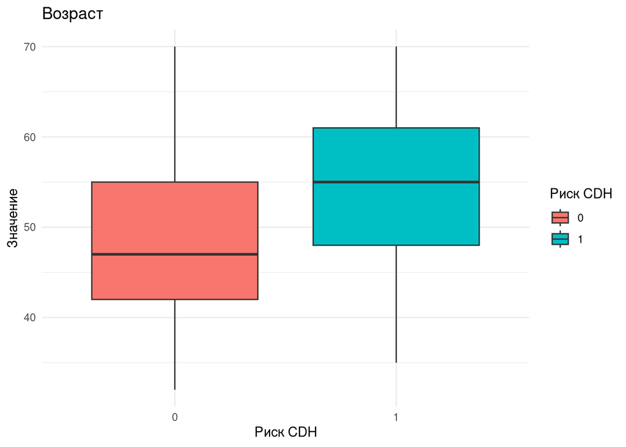

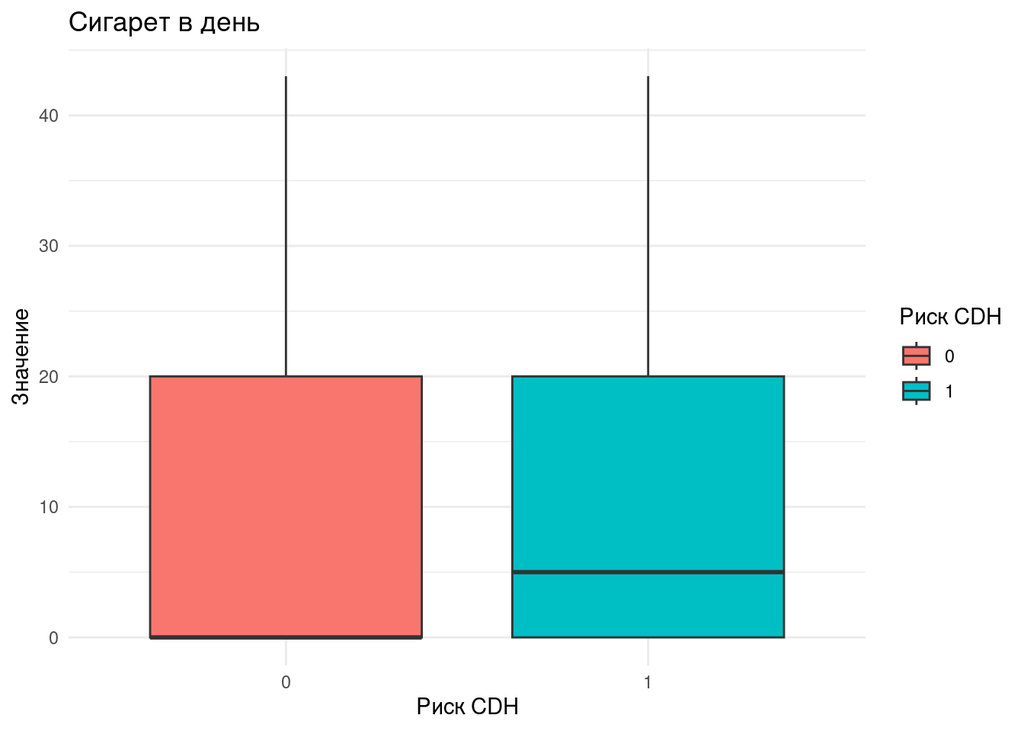

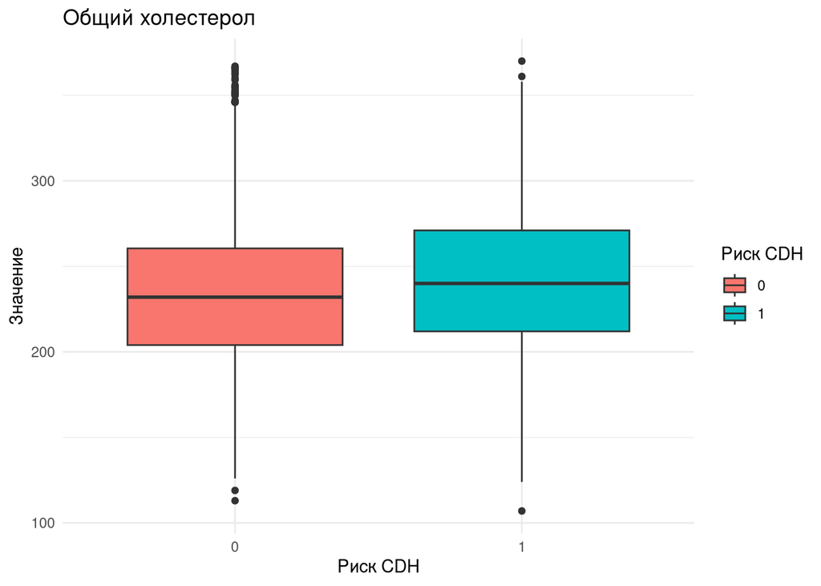

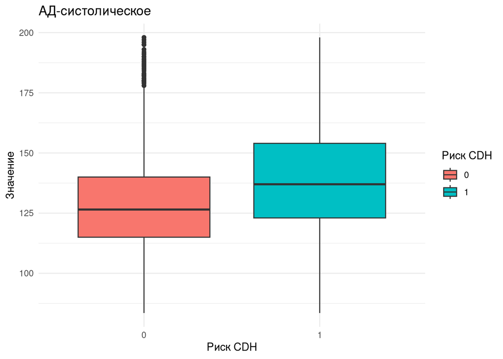

[4 more figures not shown]

```r
library(RColorBrewer)

df_long <- cleaned_data %>%
  pivot_longer(cols = all_of(numeric_vars), names_to = "Переменная", values_to = "Значение")

plot_list <- lapply(numeric_vars, function(x) {
  ggplot(df_long[df_long$Переменная == x, ], aes(x = `Риск CDH`, y = Значение, fill = `Риск CDH`)) +
    geom_boxplot() +
    labs(title = x, y = "Значение") +
    theme_minimal()
})

# Отображение графиков
lapply(plot_list, print)
```

## Категориальные переменные

1. Сделайте подходящие визуализации категориальных переменных. Обоснуйте, почему выбрали именно этот тип.

# Статистические оценки

## Проверка на нормальность

1. Оцените каждую переменную на соответствие нормальному распределению с помощью теста Шапиро-Уилка. Какие из переменных являются нормальными и как как вы это поняли?

```r
shapiro_results <- numeric(length(numeric_vars))
numeric_vars_2 <- numeric_vars[numeric_vars != "ID"]

names(shapiro_results) <- numeric_vars_2

for (var in numeric_vars_2) {
if (var!="ID") {
  data <- na.omit(cleaned_data[[var]])

  shapiro_results[var] <- shapiro.test(data)$p.value
}
}

print(shapiro_results)
```

```
##              Возраст       Сигарет в день     Общий холестерол
##         2.041570e-29         1.802036e-59         2.280229e-13
##     АД-систолическое    АД-диастолическое    Индекс массы тела
##         2.123379e-31         8.353604e-16         2.356899e-15
## Частота сердцебиения              Глюкоза
##         1.678202e-21         4.287640e-36
```

```r
#По результатам Шапиро-Уилка здесь нет нормально распределенных переменных
```

2. Постройте для каждой количественной переменной QQ-плот. Отличаются ли выводы от теста Шапиро-Уилка? Какой метод вы бы предпочли и почему?

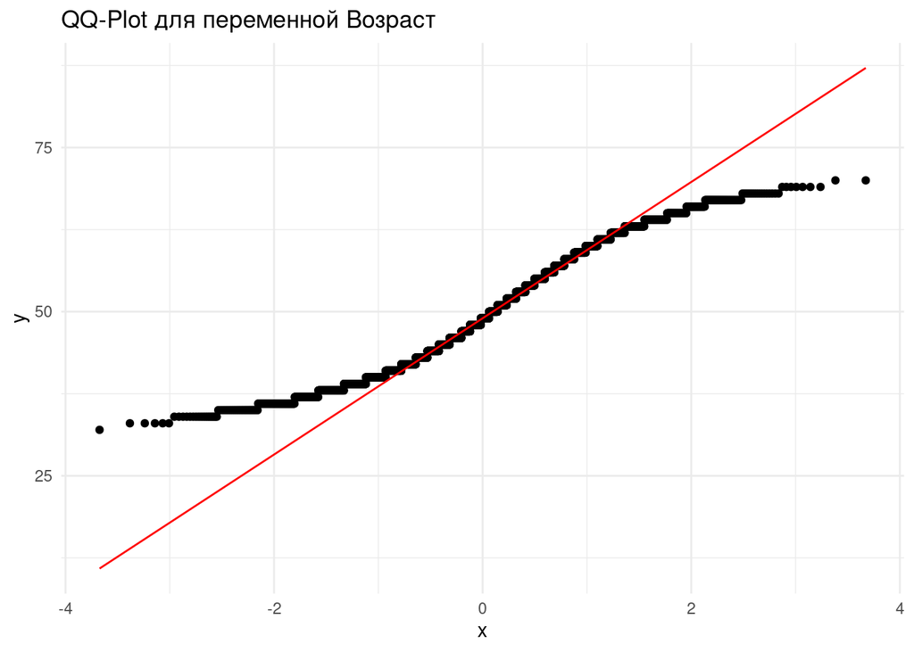

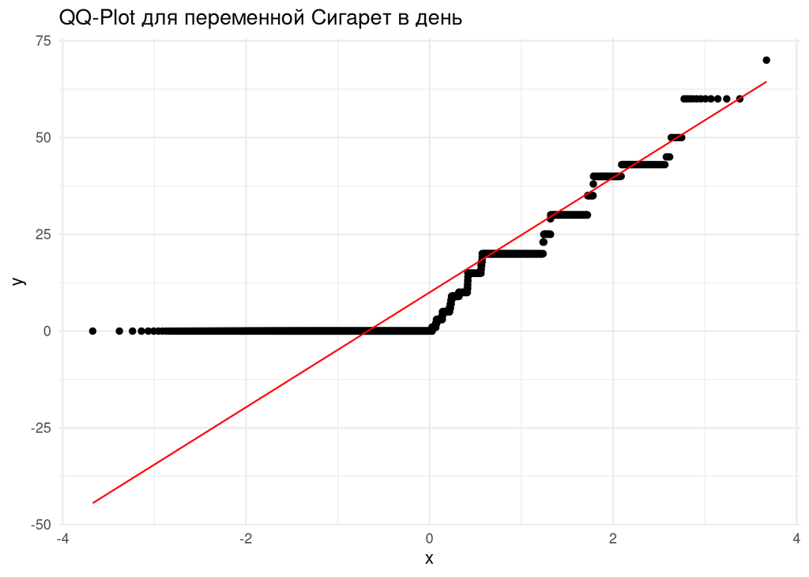

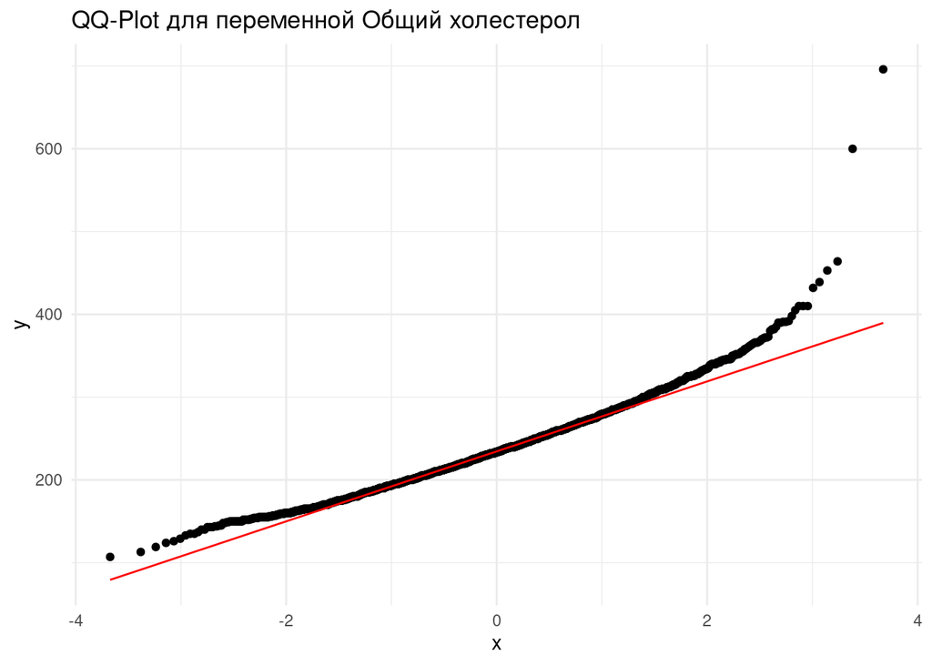

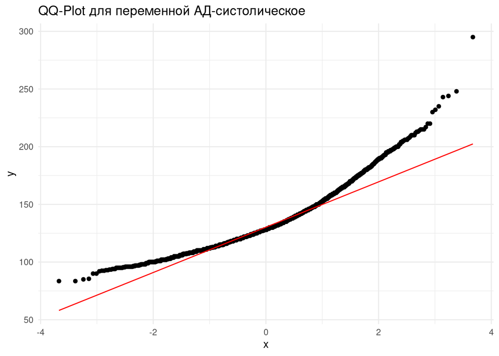

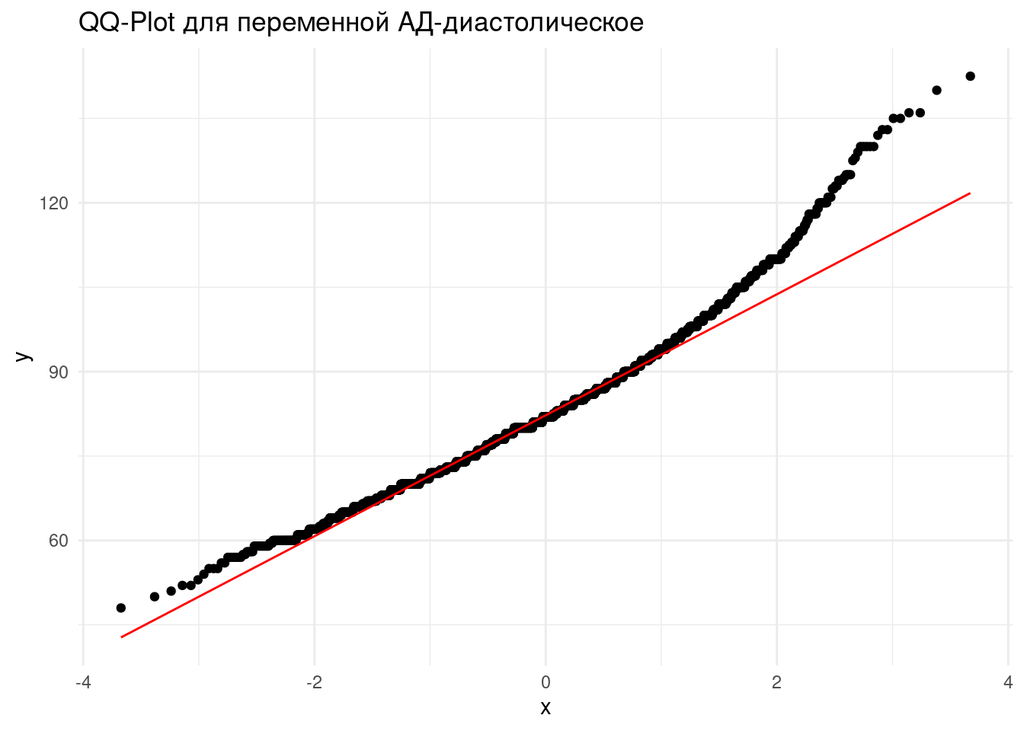

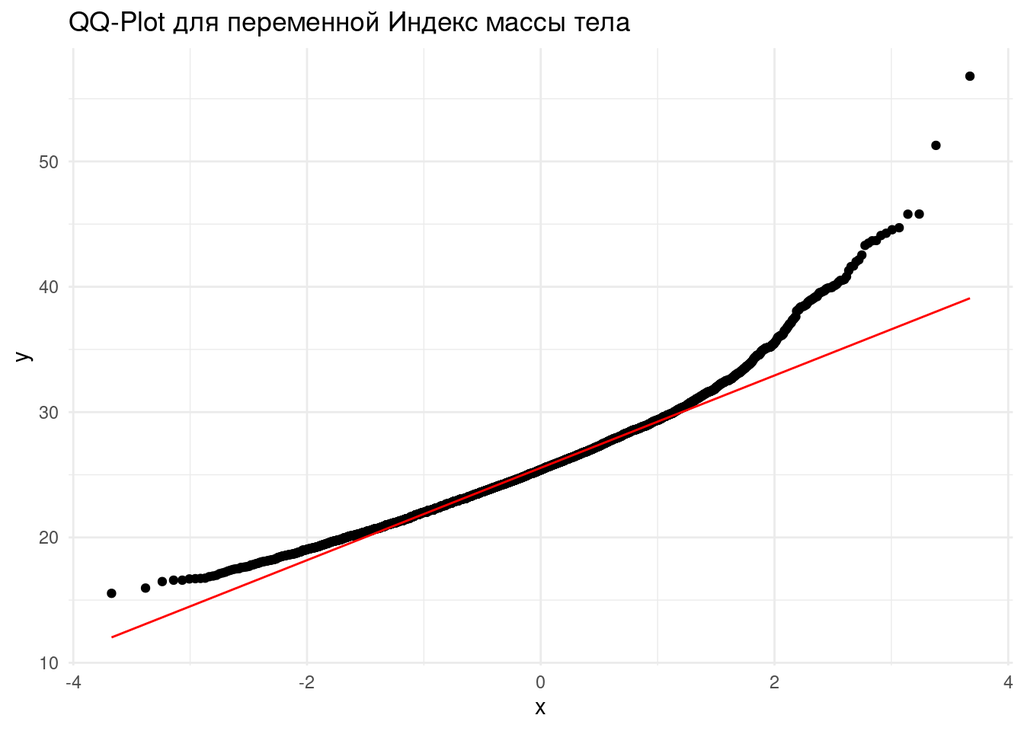

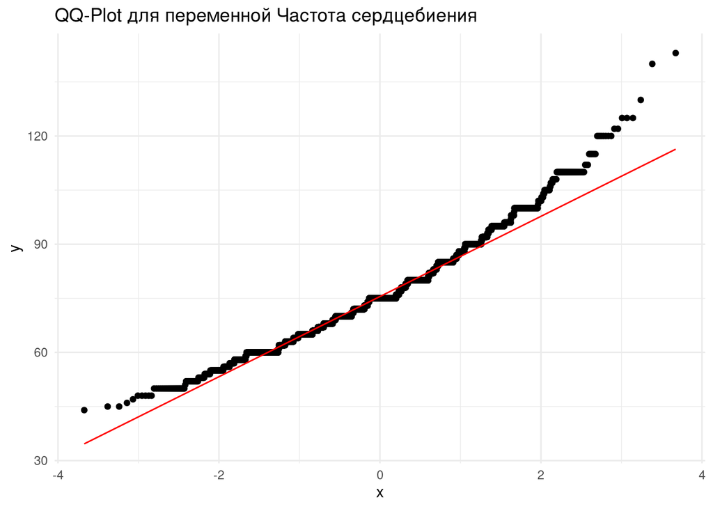

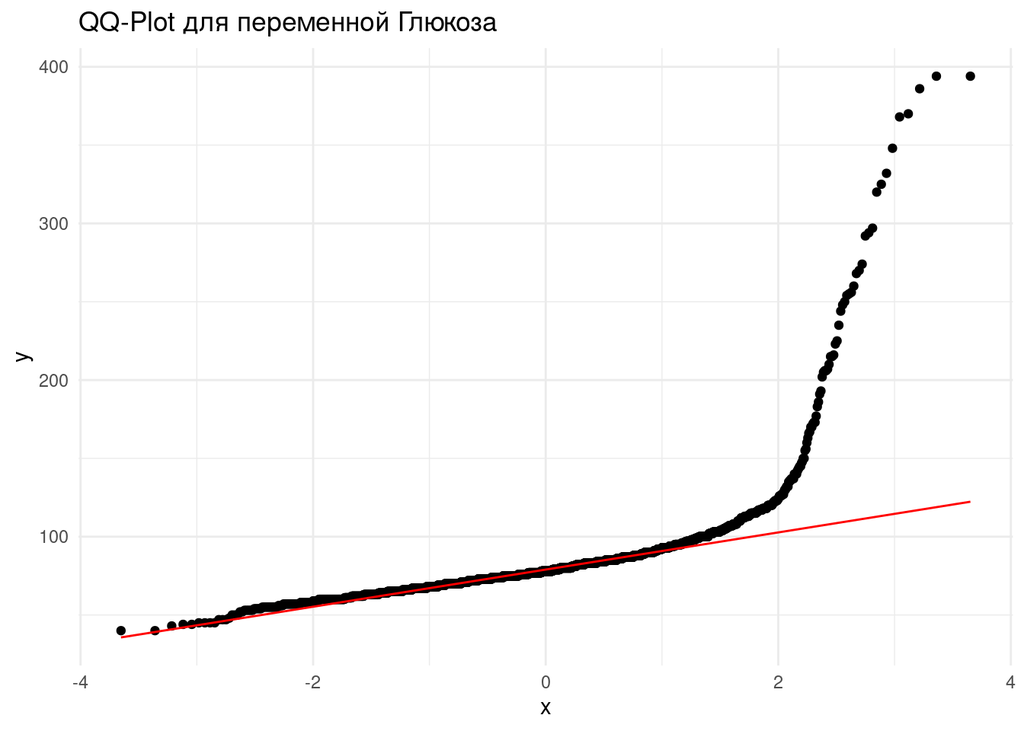

```r
plot_qq <- function(data, var_name) {
  ggplot(data, aes(sample = !!sym(var_name))) +
    geom_qq() +
    geom_qq_line(color = "red") +
    ggtitle(paste("QQ-Plot для переменной", var_name)) +
    theme_minimal()
}

# Применяем функцию к каждой количественной переменной
for (var in numeric_vars) {
  print(plot_qq(df_clean, var))
}
```

```r
#На QQ-плоте некоторые переменные кажутся вполне нормально распределенными с небольшими отклонениями на концах. Например, переменные с давлением, частотой сердцебиения, в то время как тест Шапиро-Уилка однозначно определяет их как не нормально распределенные. Лучше использовать комбинацию методов для оценки характера распределения.
```

3. Ниже напишите, какие ещё методы проверки на нормальность вы знаете и какие у них есть ограничения.

**Напишите текст здесь** Можно просто сравнить форму гистограммы данного распределения с формой нормального распределения, ограничение в неточности и примерности. Также есть другие статистические тесты. Например, тест Колмогорова-Сирнова (этот тест менее мощный, то есть с меньшей вероятностью отвергнуть нулевую гипотезу, когда альтернативная верна)

## Сравнение групп

1. Сравните группы (переменная **TenYearCHD**) по каждой переменной (как количественной, так и категориальной). Для каждой переменной выберите нужный критерий и кратко обоснуйте его выбор в комментариях.

```r
#Количественные
num_results_df <- data.frame(variable = character(), p.value = numeric())

#тест Манна-Уитни
for (var in numeric_vars) {
  group1 <- subset(cleaned_data, `Риск CDH` == 0)[[var]]
  group2 <- subset(cleaned_data, `Риск CDH` == 1)[[var]]

  test_result <- wilcox.test(group1, group2)

  num_results_df <- rbind(num_results_df, data.frame(variable = var, p.value = test_result$p.value))
}


significant_vars <- num_results_df[num_results_df$p.value < 0.05, "variable"]
significant_vars
```

```
## [1] "Возраст"           "Сигарет в день"    "Общий холестерол"
## [4] "АД-систолическое"  "АД-диастолическое" "Индекс массы тела"
```

```r
num_results_df
```

| variable | p.value |
| --- | --- |
| Возраст | 2.523552e-43 |
| Сигарет в день | 4.718095e-04 |
| Общий холестерол | 1.081712e-05 |
| АД-систолическое | 4.451194e-27 |
| АД-диастолическое | 1.005335e-11 |
| Индекс массы тела | 1.735498e-04 |
| Частота сердцебиения | 5.827855e-01 |
| Глюкоза | 1.205497e-01 |

```r
#Группы риска CDH статистически значимо различаются по уровню 0.05 по следующим переменным: Возраст, Сигарет в день, Общий холестерол, АД-систолическое, АД-диастолическое, Индекс массы тела.
```

```r
#Категориальные
chi2_results <- data.frame(variable = character(), p.value = numeric())

# Проходим по каждой категориальной переменной и проводим тест Хи-квадрат
for (var in categorical_vars) {
  table_data <- table(cleaned_data[[var]], cleaned_data$`Риск CDH`)

  # Проверяем условие ожидаемого количества наблюдений > 5
  if (all(chisq.test(table_data)$expected >= 5)) {
    test_result <- chisq.test(table_data)
    chi2_results <- rbind(chi2_results, data.frame(variable = var, p.value = test_result$p.value))
  } else {
    chi2_results <- rbind(chi2_results, data.frame(variable = var, p.value = NA))
  }
}
significant_vars_2 <- chi2_results[chi2_results$p.value < 0.05, "variable"]
significant_vars_2
```

```
## [1] "Мужской пол"                 "Образование"
## [3] "Антигипертоническая терапия" NA
## [5] "Гипертензия"
```

```r
chi2_results
```

| variable | p.value |
| --- | --- |
| Мужской пол | 1.059709e-09 |
| Образование | 1.647796e-06 |
| Курит | 6.686898e-02 |
| Антигипертоническая терапия | 1.024742e-03 |
| Инсульт | NA |
| Гипертензия | 8.292761e-23 |
| Диабет | 1.297317e-01 |

```r
#Группы риска CDH статистически значимо различаются по уровню 0.05 по следующим переменным:Мужской пол, Образование, Антигипертоническая терапия, Гипертензия.
```

# Далее идут **необязательные** дополнительные задания, которые могут принести вам дополнительные баллы в том числе в случае ошибок в предыдущих

## Корреляционный анализ

1. Создайте корреляционную матрицу с визуализацией и поправкой на множественные сравнения. Объясните, когда лучше использовать корреляционные матрицы и в чём минусы и плюсы корреляционных исследований.

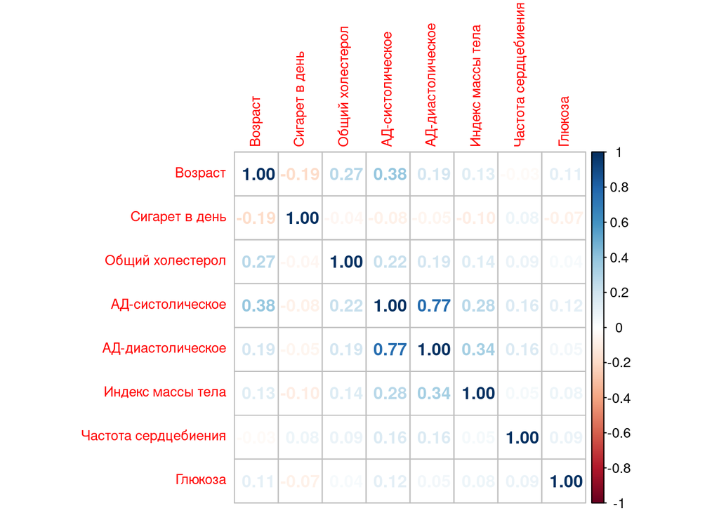

```r
#install.packages("corrplot")
library(corrplot)
cleaned_data_num <- cleaned_data %>%
  select(where(is.numeric))

df_cor <- cor(cleaned_data_num, use = "complete.obs")
adjusted_df_cor <- p.adjust(df_cor, method = "bonferroni")

corrplot(df_cor, method = 'number', number.cex = 1, tl.cex = 0.8)
```

```r
#Корреляционные матрицы нужны для оценки взаимосвязи переменных, корреляционный анализ можно использовать для первичного анализа, чтобы лучше понять структуру данных и подготовить к дальнейшему статистическому анализу. Минусы в том, что корреляция не означает причинно-следственных связей, такой анализ может быть чувствителен к выбросам.
```

## Моделирование

1. Постройте регрессионную модель для переменной **TenYearCHD**. Опишите процесс построения

```r
#Риск CDH - категориальная биномиальная переменная, для которой можно применить логистическую регрессию


model <- glm(`Риск CDH` ~ `Возраст` + `Мужской пол` + `Общий холестерол`,
            data = cleaned_data,
            family = "binomial")
summary(model)
```

```
##
## Call:
## glm(formula = `Риск CDH` ~ Возраст + `Мужской пол` +
##     `Общий холестерол`, family = "binomial", data = cleaned_data)
##
## Coefficients:
##                     Estimate Std. Error z value Pr(>|z|)
## (Intercept)        -6.612318   0.399896 -16.535  < 2e-16 ***
## Возраст             0.076142   0.005801  13.125  < 2e-16 ***
## `Мужской пол`Да     0.647012   0.096925   6.675 2.47e-11 ***
## `Общий холестерол`  0.002395   0.001176   2.037   0.0417 *
## ---
## Signif. codes:  0 '***' 0.001 '**' 0.01 '*' 0.05 '.' 0.1 ' ' 1
##
## (Dispersion parameter for binomial family taken to be 1)
##
##     Null deviance: 3189.5  on 3941  degrees of freedom
## Residual deviance: 2946.2  on 3938  degrees of freedom
##   (9 observations deleted due to missingness)
## AIC: 2954.2
##
## Number of Fisher Scoring iterations: 5
```

```r
model2 <- glm(`Риск CDH` ~ .,
            data = cleaned_data,
            family = "binomial")
summary(model2)
```

```
##
## Call:
## glm(formula = `Риск CDH` ~ ., family = "binomial", data = cleaned_data)
##
## Coefficients:
##                                  Estimate Std. Error z value Pr(>|z|)
## (Intercept)                    -7.8302764  0.8227556  -9.517  < 2e-16 ***
## `Мужской пол`Да                 0.5296531  0.1158893   4.570 4.87e-06 ***
## Возраст                         0.0675993  0.0071123   9.505  < 2e-16 ***
## Образование2                   -0.1549725  0.1291723  -1.200 0.230242
## Образование3                   -0.2560801  0.1610803  -1.590 0.111887
## Образование4                   -0.0114286  0.1698408  -0.067 0.946351
## Курит1                         -0.0514989  0.1715077  -0.300 0.763970
## `Сигарет в день`                0.0246784  0.0070169   3.517 0.000436 ***
## `Антигипертоническая терапия`1 -0.0581850  0.2724806  -0.214 0.830907
## Инсульт1                        0.9403434  0.5297965   1.775 0.075912 .
## Гипертензия1                    0.2586770  0.1503603   1.720 0.085363 .
## Диабет1                         0.0909730  0.3871630   0.235 0.814229
## `Общий холестерол`              0.0015508  0.0013000   1.193 0.232899
## `АД-систолическое`              0.0166510  0.0044475   3.744 0.000181 ***
## `АД-диастолическое`            -0.0098010  0.0072121  -1.359 0.174157
## `Индекс массы тела`             0.0037962  0.0155039   0.245 0.806570
## `Частота сердцебиения`         -0.0007213  0.0047044  -0.153 0.878135
## Глюкоза                         0.0026513  0.0038225   0.694 0.487927
## ---
## Signif. codes:  0 '***' 0.001 '**' 0.01 '*' 0.05 '.' 0.1 ' ' 1
##
## (Dispersion parameter for binomial family taken to be 1)
##
##     Null deviance: 2799.7  on 3455  degrees of freedom
## Residual deviance: 2498.7  on 3438  degrees of freedom
##   (495 observations deleted due to missingness)
## AIC: 2534.7
##
## Number of Fisher Scoring iterations: 5
```

```r
# Переменные Мужской пол, Возраст, Сигарет в день и АД-систолическое имеют p-value меньше 0.05, что делает их статистически значимыми.
```